# Pertemuan 3 - Regresi dengan Peubah Lag

Farhan Abdillah Harahap

## *Packages*

##Penjelasan Data Data “Wind Power Forecasting” dapat diakses melalui https://www.kaggle.com/datasets/theforcecoder/wind-power-forecasting. Data ini berisi berbagai fitur cuaca, turbin dan rotor. Data dicatat dari Januari 2018 hingga Maret 2020. Pembacaan dicatat dengan interval 10 menit. Berikut adalah informasi data yang digunakan pada penelitian ini:

```r
data <- data.frame(
  Kode = c("Yt", "Xt"),
  Variabel = c("Active Power", "GearboxBearingTemperature")
)
data
```

```
##   Kode                  Variabel
## 1   Yt              Active Power
## 2   Xt GearboxBearingTemperature
```

## Impor Data

```r
data <- rio::import("https://raw.githubusercontent.com/farhanabdillahh/PraktikumMPDW/main/Pertemuan%203/datasetmpdwpert3.csv")
str(data)
```

```
## 'data.frame':    657 obs. of  3 variables:
##  $ Yt    : num  1719 1721 1721 1737 1721 ...
##  $ Y(t-1): num  NA 1719 1721 1721 1737 ...
##  $ Xt    : num  1756 1753 1751 1749 1761 ...
```

```r
data
```

```
##            Yt    Y(t-1)       Xt
## 1   1718.9238        NA 1755.541
## 2   1721.0008 1718.9238 1753.030
## 3   1720.7423 1721.0008 1751.392
## 4   1736.6910 1720.7423 1749.349
## 5   1720.9785 1736.6910 1761.340
## 6   1719.4722 1720.9785 1751.928
## 7   1722.7363 1719.4722 1749.080
## 8   1717.7414 1722.7363 1752.741
## 9   1728.8675 1717.7414 1754.130
## 10  1715.2249 1728.8675 1755.110
## 11  1722.2565 1715.2249 1754.794
## 12  1714.9311 1722.2565 1751.690
## 13  1719.4720 1714.9311 1751.945
## 14  1717.1359 1719.4720 1755.809
```

[output cut: 643 more lines]

##Eksplorasi Data

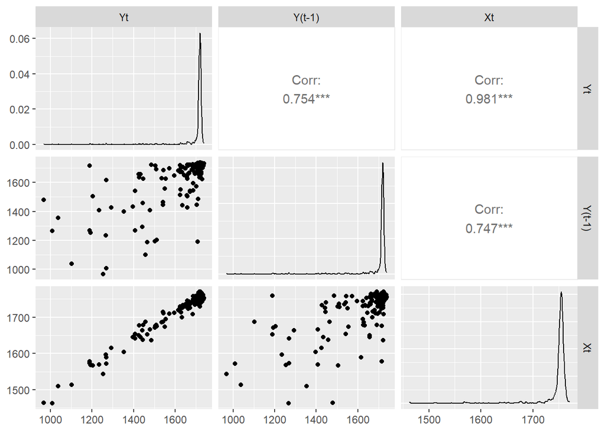

```r
ggpairs(data[sapply(data, is.numeric)])
```

## Pembagian Data

```r
#SPLIT DATA
train<-data[1:525,]
test<-data[526:657,]
```

```r
#data time series
train.ts<-ts(train)
test.ts<-ts(test)
data.ts<-ts(data)
```

## Model Koyck

Model Koyck didasarkan pada asumsi bahwa semakin jauh jarak lag peubah independen dari periode sekarang maka semakin kecil pengaruh peubah lag terhadap peubah dependen.

Koyck mengusulkan suatu metode untuk menduga model dinamis distributed lag dengan mengasumsikan bahwa semua koefisien $\beta$ mempunyai tanda sama.

Model kyock merupakan jenis paling umum dari model infinite distributed lag dan juga dikenal sebagai geometric lag

$$y_t=a(1-\lambda)+\beta_0X_t+\beta_1Z_t+\lambda Y_{t-1}+V_t$$

dengan
$$V_t=u_t-\lambda
u_{t-1}$$

### Pemodelan

Pemodelan model Koyck dengan `R` dapat menggunakan `dLagM::koyckDlm()` . Fungsi umum dari `koyckDlm` adalah sebagai berikut.

```r
koyckDlm(x , y , intercept)
```

Fungsi `koyckDlm()` akan menerapkan model lag terdistribusi dengan transformasi Koyck satu prediktor. Nilai `x` dan `y` tidak perlu sebagai objek *time series* (`ts`). `intercept` dapat dibuat `TRUE` untuk memasukkan intersep ke dalam model.

```r
#MODEL KOYCK
model.koyck <- koyckDlm(x = train$Xt, y = train$Yt)
summary(model.koyck)
```

```
##
## Call:
## "Y ~ (Intercept) + Y.1 + X.t"
##
## Residuals:
##      Min       1Q   Median       3Q      Max
## -324.884  -19.435   -2.915   12.381  405.821
##
## Coefficients:
##               Estimate Std. Error t value Pr(>|t|)
## (Intercept) -6582.8497  4035.4717  -1.631   0.1034
## Y.1            -0.6861     0.8303  -0.826   0.4090
## X.t             5.4077     3.1159   1.736   0.0832 .
## ---
## Signif. codes:  0 '***' 0.001 '**' 0.01 '*' 0.05 '.' 0.1 ' ' 1
##
## Residual standard error: 53.44 on 521 degrees of freedom
## Multiple R-Squared: 0.372,   Adjusted R-squared: 0.3696
## Wald test: 236.5 on 2 and 521 DF,  p-value: < 2.2e-16
##
## Diagnostic tests:
## NULL
##
##                              alpha     beta        phi
## Geometric coefficients:  -3904.146 5.407718 -0.6861179
```

```r
AIC(model.koyck)
```

```
## [1] 5661.535
```

```r
BIC(model.koyck)
```

```
## [1] 5678.581
```

$$\hat{Y_t}=-6582.8497+5.4077X_t-0.6861Y_{t-1}$$

### Peramalan dan Akurasi

Berikut adalah hasil peramalan y untuk 132 periode kedepan menggunakan model koyck

```r
fore.koyck <- forecast(model = model.koyck, x=test$Xt, h=132)
fore.koyck
```

```
## $forecasts
##   [1] 1415.2386 1834.2016 1673.4054 1699.3319 1666.0126 1625.3768 1562.3991
##   [8] 1780.0223 1612.0086 1851.9419  677.3816 1890.9701 1246.6396 1502.3380
##  [15]  870.2824 1453.2197  326.8217 1694.7739 1128.5500 1654.7767  195.6861
##  [22] 1627.6438  779.2266 1916.8569 1452.5355 1913.5237 1570.6117 1837.2942
##  [29] 1640.8433 1762.1100 1671.4204 1755.1397 1682.1487 1758.4078 1700.1570
##  [36] 1700.3149 1700.9692 1766.1292 1700.8002 1702.9874 1599.8404 1812.7696
##  [43] 1655.2689 1824.9107 1613.0197 1789.2554 1616.7365 1768.9502 1730.4561
##  [50] 1686.4227 1755.7438 1700.4434 1743.0507 1726.0413 1672.8862 1735.4616
##  [57] 1747.7768 1720.5604 1706.2647 1740.0319 1677.4262 1752.6843 1673.9496
##  [64] 1783.5387 1662.7491 1839.2769 1695.4872 1724.7975 1679.7081 1789.0369
##  [71] 1509.9361 1768.5727 1651.9944 1690.3040 1655.9252 1784.9779 1641.9801
##  [78] 1747.6944 1714.1219 1722.4084 1737.6182 1652.9406 1708.6214 1778.3623
##  [85] 1698.2501 1806.8504 1616.8379 1880.0909 1622.9016 1796.7315 1637.4315
##  [92] 1817.5312 1583.6198 1627.0556  895.6306 1310.9378 2030.7612 1555.0390
##  [99] 1830.5446 1635.3454 1683.3774 1759.1625 1655.0262 1725.0036 1659.8147
## [106] 1527.4487 1877.2141 1669.2017 1802.6931 1673.4268 1727.7535 1724.0771
## [113] 1665.3172 1798.3314 1680.6119 1726.8135 1720.3691 1699.8612 1689.1341
## [120] 1661.5750 1814.8853 1642.4429 1768.9792 1673.4227 1752.3249 1724.0233
## [127] 1618.4683 1667.5728 1749.8400 1547.4894 1633.9709 1727.9918
##
## $call
## forecast.koyckDlm(model = model.koyck, x = test$Xt, h = 132)
##
## attr(,"class")
## [1] "forecast.koyckDlm" "dLagM"
```

```r
mape.koyck <- MAPE(fore.koyck$forecasts, test$Yt)
#akurasi data training
GoF(model.koyck)
```

```
##               n      MAE          MPE       MAPE      sMAPE     MASE      MSE
## model.koyck 524 28.14549 0.0009069839 0.01760234 0.01803766 1.651363 2839.297
##                 MRAE    GMRAE
## model.koyck 8.346847 2.566818
```

## Regression with Distributed Lag

Pemodelan model Regression with Distributed Lag dengan `R` dapat menggunakan `dLagM::dlm()` . Fungsi umum dari `dlm` adalah sebagai berikut.

```r
dlm(formula , data , x , y , q , remove )
```

Fungsi `dlm()` akan menerapkan model lag terdistribusi dengan satu atau lebih prediktor. Nilai `x` dan `y` tidak perlu sebagai objek *time series* (`ts`). $q$ adalah integer yang mewakili panjang *lag* yang terbatas.

### Pemodelan (Lag=2)

```r
model.dlm <- dlm(x = train$Xt,y = train$Yt , q = 2)
summary(model.dlm)
```

```
##
## Call:
## lm(formula = model.formula, data = design)
##
## Residuals:
##     Min      1Q  Median      3Q     Max
## -86.249  -7.694  -0.446   8.374  77.348
##
## Coefficients:
##               Estimate Std. Error t value Pr(>|t|)
## (Intercept) -3.052e+03  5.339e+01 -57.178  < 2e-16 ***
## x.t          2.419e+00  3.793e-02  63.780  < 2e-16 ***
## x.1          3.337e-01  4.500e-02   7.416 4.95e-13 ***
## x.2         -3.298e-02  3.809e-02  -0.866    0.387
## ---
## Signif. codes:  0 '***' 0.001 '**' 0.01 '*' 0.05 '.' 0.1 ' ' 1
##
## Residual standard error: 15.1 on 519 degrees of freedom
## Multiple R-squared:   0.95,  Adjusted R-squared:  0.9497
## F-statistic:  3290 on 3 and 519 DF,  p-value: < 2.2e-16
##
## AIC and BIC values for the model:
##        AIC      BIC
## 1 4329.837 4351.135
```

```r
AIC(model.dlm)
```

```
## [1] 4329.837
```

```r
BIC(model.dlm)
```

```
## [1] 4351.135
```

$$\hat{Y_t}=-3052+2.419X_t+0.3337X_{t-1}-0.03298X_{t-2}$$

### Peramalan dan Akurasi

Berikut merupakan hasil peramalan $y$ untuk 132 periode kedepan

```r
fore.dlm <- forecast(model = model.dlm, x=test$Xt, h=132)
fore.dlm
```

```
## $forecasts
##   [1] 1539.8824 1653.8428 1728.2246 1696.6199 1683.6902 1654.8377 1610.3632
##   [8] 1683.1763 1686.1286 1739.6825 1295.6388 1414.9580 1530.5406 1456.2860
##  [15] 1239.3421 1279.0841  966.0713 1186.5843 1394.3344 1475.3056  990.2677
##  [22] 1114.4265 1207.6990 1461.8861 1636.8335 1716.6757 1711.6259 1723.1650
##  [29] 1719.2366 1712.1637 1708.0620 1717.2997 1711.7149 1722.3366 1721.3948
##  [36] 1703.0586 1700.9791 1730.6227 1725.4409 1704.6925 1656.7100 1714.2991
##  [43] 1718.5892 1744.5685 1705.7126 1713.2474 1692.6477 1704.4176 1736.3241
##  [50] 1708.6699 1721.4177 1720.7990 1722.1699 1727.9742 1699.6969 1707.3010
##  [57] 1734.0263 1728.8804 1712.6346 1721.4336 1705.4688 1717.3414 1707.4514
##  [64] 1730.4433 1713.6369 1752.3842 1748.2990 1715.3027 1699.9856 1733.9400
##  [71] 1647.6202 1664.5858 1697.2107 1681.9118 1675.3471 1722.2873 1704.4831
##  [78] 1703.8800 1722.1121 1717.8718 1726.0726 1694.2360 1688.4449 1737.0433
##  [85] 1729.2858 1750.6325 1702.4641 1754.4609 1729.1099 1722.3964 1704.7903
##  [92] 1734.0126 1689.2588 1629.6463 1309.1858 1227.8823 1676.3612 1747.0240
##  [99] 1719.2456 1713.2333 1674.7319 1718.1195 1702.0272 1697.4875 1690.0299
## [106] 1609.7465 1714.7760 1746.1395 1742.4037 1724.7829 1707.1389 1720.2798
## [113] 1695.1449 1732.6315 1726.8895 1709.2256 1718.5530 1709.1688 1696.3816
## [120] 1679.3802 1737.5083 1715.9263 1714.6339 1711.6422 1717.0208 1729.4559
## [127] 1675.0553 1656.7521 1707.9557 1649.9754 1616.8398 1683.1115
##
## $call
## forecast.dlm(model = model.dlm, x = test$Xt, h = 132)
##
## attr(,"class")
## [1] "forecast.dlm" "dLagM"
```

```r
mape.dlm <- MAPE(fore.dlm$forecasts, test$Yt)
#akurasi data training
GoF(model.dlm)
```

```
##             n      MAE           MPE        MAPE       sMAPE      MASE      MSE
## model.dlm 523 10.63619 -9.818974e-05 0.006412731 0.006409548 0.6228752 226.2973
##               MRAE    GMRAE
## model.dlm 3.700708 1.144466
```

### *Lag* Optimum

```r
#penentuan lag optimum
finiteDLMauto(formula = Yt ~ Xt,
              data = data.frame(train), q.min = 1, q.max = 6,
              model.type = "dlm", error.type = "AIC", trace = FALSE)
```

```
##   q - k    MASE      AIC      BIC   GMRAE   MBRAE R.Adj.Sq Ljung-Box
## 6     6 0.61744 4297.928 4336.195 1.14827 0.69062  0.95036 0.5794513
```

Berdasarkan output tersebut, lag optimum didapatkan ketika lag=6 Selanjutnya dilakukan pemodelan untuk lag=6

```r
#model dlm dengan lag optimum
model.dlm2 <- dlm(x = train$Xt,y = train$Yt , q = 6)
summary(model.dlm2)
```

```
##
## Call:
## lm(formula = model.formula, data = design)
##
## Residuals:
##     Min      1Q  Median      3Q     Max
## -82.228  -7.780  -0.343   7.760  77.130
##
## Coefficients:
##               Estimate Std. Error t value Pr(>|t|)
## (Intercept) -3.069e+03  6.343e+01 -48.384  < 2e-16 ***
## x.t          2.407e+00  3.852e-02  62.491  < 2e-16 ***
## x.1          3.378e-01  4.548e-02   7.427  4.7e-13 ***
## x.2         -2.531e-02  4.545e-02  -0.557   0.5779
## x.3          5.374e-03  4.543e-02   0.118   0.9059
## x.4          1.231e-02  4.547e-02   0.271   0.7867
## x.5         -9.037e-02  4.552e-02  -1.985   0.0476 *
## x.6          8.246e-02  3.869e-02   2.131   0.0335 *
## ---
## Signif. codes:  0 '***' 0.001 '**' 0.01 '*' 0.05 '.' 0.1 ' ' 1
##
## Residual standard error: 15.06 on 511 degrees of freedom
## Multiple R-squared:  0.951,  Adjusted R-squared:  0.9504
## F-statistic:  1418 on 7 and 511 DF,  p-value: < 2.2e-16
##
## AIC and BIC values for the model:
##        AIC      BIC
## 1 4297.928 4336.195
```

```r
AIC(model.dlm2)
```

```
## [1] 4297.928
```

```r
BIC(model.dlm2)
```

```
## [1] 4336.195
```

Adapun hasil peramalan 132 periode kedepan menggunakan model tersebut adalah sebagai berikut

```r
#peramalan dan akurasi
fore.dlm2 <- forecast(model = model.dlm2, x=test$Xt, h=132)
mape.dlm2<- MAPE(fore.dlm2$forecasts, test$Yt)
#akurasi data training
GoF(model.dlm2)
```

```
##              n      MAE           MPE        MAPE       sMAPE      MASE
## model.dlm2 519 10.58133 -9.805907e-05 0.006390739 0.006388159 0.6174382
##                 MSE     MRAE    GMRAE
## model.dlm2 223.3214 3.719407 1.148274
```

Model tersebut merupakan model yang sangat baik dengan nilai MAPE yang kurang dari 10%.

## Model Autoregressive

Peubah dependen dipengaruhi oleh peubah independen pada waktu sekarang, serta dipengaruhi juga oleh peubah dependen itu sendiri pada satu waktu yang lalu maka model tersebut disebut *autoregressive* (Gujarati 2004).

### Pemodelan

Pemodelan Autoregressive dilakukan menggunakan fungsi `dLagM::ardlDlm()` . Fungsi tersebut akan menerapkan *autoregressive* berordo $(p,q)$ dengan satu prediktor. Fungsi umum dari `ardlDlm()` adalah sebagai berikut.

```r
ardlDlm(formula = NULL , data = NULL , x = NULL , y = NULL , p = 1 , q = 1 ,
         remove = NULL )
```

Dengan $p$ adalah integer yang mewakili panjang *lag* yang terbatas dan $q$ adalah integer yang merepresentasikan ordo dari proses *autoregressive*.

```r
model.ardl <- ardlDlm(x = train$Xt, y = train$Yt, p = 1 , q = 1)
summary(model.ardl)
```

```
##
## Time series regression with "ts" data:
## Start = 2, End = 525
##
## Call:
## dynlm(formula = as.formula(model.text), data = data, start = 1)
##
## Residuals:
##     Min      1Q  Median      3Q     Max
## -85.452  -7.590  -0.390   8.387  77.376
##
## Coefficients:
##               Estimate Std. Error t value Pr(>|t|)
## (Intercept) -3.149e+03  1.363e+02 -23.110  < 2e-16 ***
## X.t          2.421e+00  3.852e-02  62.856  < 2e-16 ***
## X.1          3.805e-01  1.122e-01   3.390 0.000751 ***
## Y.1         -2.703e-02  4.213e-02  -0.642 0.521462
## ---
## Signif. codes:  0 '***' 0.001 '**' 0.01 '*' 0.05 '.' 0.1 ' ' 1
##
## Residual standard error: 15.09 on 520 degrees of freedom
## Multiple R-squared:   0.95,  Adjusted R-squared:  0.9497
## F-statistic:  3294 on 3 and 520 DF,  p-value: < 2.2e-16
```

```r
AIC(model.ardl)
```

```
## [1] 4337.512
```

```r
BIC(model.ardl)
```

```
## [1] 4358.819
```

### Peramalan dan Akurasi

```r
fore.ardl <- forecast(model = model.ardl, x=test$Xt, h=132)
fore.ardl
```

```
## $forecasts
##   [1] 1540.1939 1654.1370 1726.9335 1696.0913 1684.0328 1654.8369 1610.4785
##   [8] 1683.3730 1685.3035 1739.7471 1294.8745 1418.3719 1528.0434 1454.8810
##  [15] 1239.3056 1279.8352  964.0019 1187.8675 1390.4025 1472.7940  988.6420
##  [22] 1117.3657 1204.2314 1460.0352 1633.7923 1715.1071 1711.0116 1723.3097
##  [29] 1719.1539 1712.2640 1708.1470 1717.3556 1711.6572 1722.4379 1721.3345
##  [36] 1703.1238 1701.1562 1730.6377 1725.2247 1704.8308 1656.8725 1714.6639
##  [43] 1717.9980 1744.6751 1705.5309 1713.6831 1692.5311 1704.6252 1736.2038
##  [50] 1708.4506 1721.7539 1720.6817 1722.2547 1728.0135 1699.6941 1707.5858
##  [57] 1733.9457 1728.7186 1712.7782 1721.6160 1705.4059 1717.5320 1707.3445
##  [64] 1730.5920 1713.4581 1752.6428 1748.0233 1715.5049 1700.3206 1734.0713
##  [71] 1647.3001 1665.3451 1696.8377 1681.6104 1675.4655 1722.2811 1704.0572
##  [78] 1704.1213 1722.0977 1717.7502 1726.1852 1694.1877 1688.7460 1737.0521
##  [85] 1728.8977 1750.8612 1702.3295 1755.0084 1728.6541 1722.8003 1704.8500
##  [92] 1734.2176 1689.0032 1630.0528 1309.2768 1229.8327 1675.7508 1742.5306
##  [99] 1719.2164 1713.5029 1674.7648 1718.4534 1701.5803 1697.7084 1690.0193
## [106] 1609.7298 1715.3751 1745.0532 1742.3682 1724.9232 1707.3575 1720.4568
## [113] 1695.0294 1732.9076 1726.5614 1709.3946 1718.7336 1709.0968 1696.5005
## [120] 1679.4619 1737.6400 1715.4138 1714.9627 1711.6413 1717.0885 1729.4466
## [127] 1674.9771 1657.2152 1707.9719 1649.4341 1617.3091 1683.1551
##
## $call
## forecast.ardlDlm(model = model.ardl, x = test$Xt, h = 132)
##
## attr(,"class")
## [1] "forecast.ardlDlm" "dLagM"
```

Data di atas merupakan hasil peramalan untuk 132 periode ke depan menggunakan Model Autoregressive dengan $p=1$ dan $q=1$.

```r
mape.ardl <- MAPE(fore.ardl$forecasts, test$Yt)
mape.ardl
```

```
## [1] 0.01178092
```

```r
#akurasi data training
GoF(model.ardl)
```

```
##              n     MAE           MPE       MAPE       sMAPE      MASE      MSE
## model.ardl 524 10.6413 -9.832393e-05 0.00641476 0.006411626 0.6243507 226.0448
##                MRAE    GMRAE
## model.ardl 3.777574 1.180605
```

Berdasarkan akurasi di atas, terlihat bahwa nilai MAPE keduanya tidak jauh berbeda. Artinya, model regresi dengan distribusi lag ini tidak `overfitted` atau `underfitted`

### *Lag* Optimum

```r
#penentuan lag optimum
model.ardl.opt <- ardlBoundOrders(data = data.frame(data), ic = "AIC",
                                  formula = Yt ~ Xt )
min_p=c()
for(i in 1:15){
  min_p[i]=min(model.ardl.opt$Stat.table[[i]])
}
q_opt=which(min_p==min(min_p, na.rm = TRUE))
p_opt=which(model.ardl.opt$Stat.table[[q_opt]] ==
              min(model.ardl.opt$Stat.table[[q_opt]], na.rm = TRUE))
data.frame("q_optimum" = q_opt, "p_optimum" = p_opt,
           "AIC"=model.ardl.opt$min.Stat)
```

```
##   q_optimum p_optimum     AIC
## 1        15         1 5506.95
```

Selanjutnya dapat dilakukan pemodelan dengan nilai $p$ dan $q$ optimum seperti inisialisasi di langkah sebelumnya.

## Pemodelan DLM & ARDL dengan Library `dynlm`

Pemodelan regresi dengan peubah *lag* tidak hanya dapat dilakukan dengan fungsi pada *packages* `dLagM` , tetapi terdapat *packages* `dynlm` yang dapat digunakan. Fungsi `dynlm` secara umum adalah sebagai berikut.

```r
dynlm(formula, data, subset, weights, na.action, method = "qr",
  model = TRUE, x = FALSE, y = FALSE, qr = TRUE, singular.ok = TRUE,
  contrasts = NULL, offset, start = NULL, end = NULL, ...)
```

Untuk menentukan `formula` model yang akan digunakan, tersedia fungsi tambahan yang memungkinkan spesifikasi dinamika (melalui `d()` dan `L()`) atau pola linier/siklus dengan mudah (melalui `trend()`, `season()`, dan `harmon()`). Semua fungsi formula baru mengharuskan argumennya berupa objek deret waktu (yaitu, `"ts"` atau `"zoo"`).

```r
#sama dengan model dlm q=1
cons_lm1 <- dynlm(Yt ~ Xt+L(Xt),data = train.ts)
#sama dengan model ardl p=1 q=0
cons_lm2 <- dynlm(Yt ~ Xt+L(Yt),data = train.ts)
#sama dengan ardl p=1 q=1
cons_lm3 <- dynlm(Yt ~ Xt+L(Xt)+L(Yt),data = train.ts)
#sama dengan dlm p=2
cons_lm4 <- dynlm(Yt ~ Xt+L(Xt)+L(Xt,2),data = train.ts)
```

### Ringkasan Model

```r
summary(cons_lm1)
```

```
##
## Time series regression with "ts" data:
## Start = 2, End = 525
##
## Call:
## dynlm(formula = Yt ~ Xt + L(Xt), data = train.ts)
##
## Residuals:
##     Min      1Q  Median      3Q     Max
## -87.255  -7.614  -0.404   8.256  76.944
##
## Coefficients:
##               Estimate Std. Error t value Pr(>|t|)
## (Intercept) -3.068e+03  5.041e+01 -60.858  < 2e-16 ***
## Xt           2.416e+00  3.771e-02  64.080  < 2e-16 ***
## L(Xt)        3.127e-01  3.778e-02   8.278 1.06e-15 ***
## ---
## Signif. codes:  0 '***' 0.001 '**' 0.01 '*' 0.05 '.' 0.1 ' ' 1
##
## Residual standard error: 15.08 on 521 degrees of freedom
## Multiple R-squared:   0.95,  Adjusted R-squared:  0.9498
## F-statistic:  4946 on 2 and 521 DF,  p-value: < 2.2e-16
```

```r
summary(cons_lm2)
```

```
##
## Time series regression with "ts" data:
## Start = 2, End = 525
##
## Call:
## dynlm(formula = Yt ~ Xt + L(Yt), data = train.ts)
##
## Residuals:
##     Min      1Q  Median      3Q     Max
## -94.362  -7.915  -0.010   7.852  76.640
##
## Coefficients:
##               Estimate Std. Error t value Pr(>|t|)
## (Intercept) -2.723e+03  5.310e+01 -51.274  < 2e-16 ***
## Xt           2.427e+00  3.887e-02  62.439  < 2e-16 ***
## L(Yt)        1.075e-01  1.433e-02   7.498  2.8e-13 ***
## ---
## Signif. codes:  0 '***' 0.001 '**' 0.01 '*' 0.05 '.' 0.1 ' ' 1
##
## Residual standard error: 15.24 on 521 degrees of freedom
## Multiple R-squared:  0.9489, Adjusted R-squared:  0.9487
## F-statistic:  4837 on 2 and 521 DF,  p-value: < 2.2e-16
```

```r
summary(cons_lm3)
```

```
##
## Time series regression with "ts" data:
## Start = 2, End = 525
##
## Call:
## dynlm(formula = Yt ~ Xt + L(Xt) + L(Yt), data = train.ts)
##
## Residuals:
##     Min      1Q  Median      3Q     Max
## -85.452  -7.590  -0.390   8.387  77.376
##
## Coefficients:
##               Estimate Std. Error t value Pr(>|t|)
## (Intercept) -3.149e+03  1.363e+02 -23.110  < 2e-16 ***
## Xt           2.421e+00  3.852e-02  62.856  < 2e-16 ***
## L(Xt)        3.805e-01  1.122e-01   3.390 0.000751 ***
## L(Yt)       -2.703e-02  4.213e-02  -0.642 0.521462
## ---
## Signif. codes:  0 '***' 0.001 '**' 0.01 '*' 0.05 '.' 0.1 ' ' 1
##
## Residual standard error: 15.09 on 520 degrees of freedom
## Multiple R-squared:   0.95,  Adjusted R-squared:  0.9497
## F-statistic:  3294 on 3 and 520 DF,  p-value: < 2.2e-16
```

```r
summary(cons_lm4)
```

```
##
## Time series regression with "ts" data:
## Start = 3, End = 525
##
## Call:
## dynlm(formula = Yt ~ Xt + L(Xt) + L(Xt, 2), data = train.ts)
##
## Residuals:
##     Min      1Q  Median      3Q     Max
## -86.249  -7.694  -0.446   8.374  77.348
##
## Coefficients:
##               Estimate Std. Error t value Pr(>|t|)
## (Intercept) -3.052e+03  5.339e+01 -57.178  < 2e-16 ***
## Xt           2.419e+00  3.793e-02  63.780  < 2e-16 ***
## L(Xt)        3.337e-01  4.500e-02   7.416 4.95e-13 ***
## L(Xt, 2)    -3.298e-02  3.809e-02  -0.866    0.387
## ---
## Signif. codes:  0 '***' 0.001 '**' 0.01 '*' 0.05 '.' 0.1 ' ' 1
##
## Residual standard error: 15.1 on 519 degrees of freedom
## Multiple R-squared:   0.95,  Adjusted R-squared:  0.9497
## F-statistic:  3290 on 3 and 519 DF,  p-value: < 2.2e-16
```

### SSE

```r
deviance(cons_lm1)
```

```
## [1] 118541.2
```

```r
deviance(cons_lm2)
```

```
## [1] 121066
```

```r
deviance(cons_lm3)
```

```
## [1] 118447.5
```

```r
deviance(cons_lm4)
```

```
## [1] 118353.5
```

### Uji Diagnostik

```r
#uji model
if(require("lmtest")) encomptest(cons_lm1, cons_lm2)
```

```
## Encompassing test
##
## Model 1: Yt ~ Xt + L(Xt)
## Model 2: Yt ~ Xt + L(Yt)
## Model E: Yt ~ Xt + L(Xt) + L(Yt)
##           Res.Df Df       F    Pr(>F)
## M1 vs. ME    520 -1  0.4116 0.5214622
## M2 vs. ME    520 -1 11.4954 0.0007507 ***
## ---
## Signif. codes:  0 '***' 0.001 '**' 0.01 '*' 0.05 '.' 0.1 ' ' 1
```

#### Autokorelasi

```r
#durbin watson
dwtest(cons_lm1)
```

```
##
##  Durbin-Watson test
##
## data:  cons_lm1
## DW = 2.0299, p-value = 0.6234
## alternative hypothesis: true autocorrelation is greater than 0
```

```r
dwtest(cons_lm2)
```

```
##
##  Durbin-Watson test
##
## data:  cons_lm2
## DW = 2.2461, p-value = 0.9973
## alternative hypothesis: true autocorrelation is greater than 0
```

```r
dwtest(cons_lm3)
```

```
##
##  Durbin-Watson test
##
## data:  cons_lm3
## DW = 1.9795, p-value = 0.3964
## alternative hypothesis: true autocorrelation is greater than 0
```

```r
dwtest(cons_lm4)
```

```
##
##  Durbin-Watson test
##
## data:  cons_lm4
## DW = 2.0308, p-value = 0.6272
## alternative hypothesis: true autocorrelation is greater than 0
```

#### Heterogenitas

```r
bptest(cons_lm1)
```

```
##
##  studentized Breusch-Pagan test
##
## data:  cons_lm1
## BP = 135.91, df = 2, p-value < 2.2e-16
```

```r
bptest(cons_lm2)
```

```
##
##  studentized Breusch-Pagan test
##
## data:  cons_lm2
## BP = 138.1, df = 2, p-value < 2.2e-16
```

```r
bptest(cons_lm3)
```

```
##
##  studentized Breusch-Pagan test
##
## data:  cons_lm3
## BP = 141.85, df = 3, p-value < 2.2e-16
```

```r
bptest(cons_lm4)
```

```
##
##  studentized Breusch-Pagan test
##
## data:  cons_lm4
## BP = 132, df = 3, p-value < 2.2e-16
```

#### Kenormalan

```r
shapiro.test(residuals(cons_lm1))
```

```
##
##  Shapiro-Wilk normality test
##
## data:  residuals(cons_lm1)
## W = 0.93535, p-value = 2.739e-14
```

```r
shapiro.test(residuals(cons_lm2))
```

```
##
##  Shapiro-Wilk normality test
##
## data:  residuals(cons_lm2)
## W = 0.92852, p-value = 4.179e-15
```

```r
shapiro.test(residuals(cons_lm3))
```

```
##
##  Shapiro-Wilk normality test
##
## data:  residuals(cons_lm3)
## W = 0.93759, p-value = 5.22e-14
```

```r
shapiro.test(residuals(cons_lm4))
```

```
##
##  Shapiro-Wilk normality test
##
## data:  residuals(cons_lm4)
## W = 0.936, p-value = 3.423e-14
```

## Perbandingan Model

```r
akurasi <- matrix(c(mape.koyck, mape.dlm, mape.dlm2, mape.ardl))
row.names(akurasi)<- c("Koyck","DLM 1","DLM 2","Autoregressive")
colnames(akurasi) <- c("MAPE")
akurasi
```

```
##                      MAPE
## Koyck          0.06749262
## DLM 1          0.01180144
## DLM 2          0.01209009
## Autoregressive 0.01178092
```

Berdasarkan nilai MAPE, model paling optimum didapat pada Model Autoregressive karena memiliki nilai MAPE yang terkecil.

### Plot

####Koyck

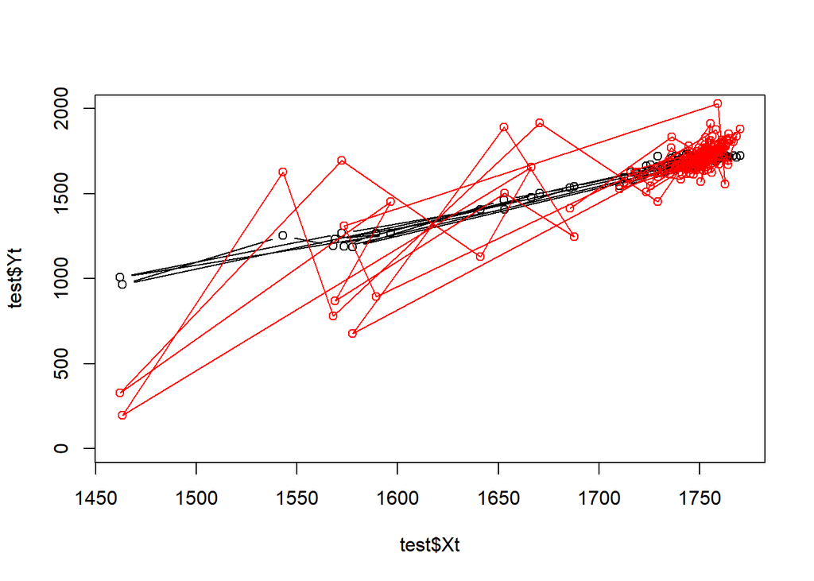

```r
par(mfrow=c(1,1))
plot(test$Xt, test$Yt, type="b", col="black", ylim=c(0,2000))
points(test$Xt, fore.koyck$forecasts,col="red")
lines(test$Xt, fore.koyck$forecasts,col="red")
```

####DLM 1

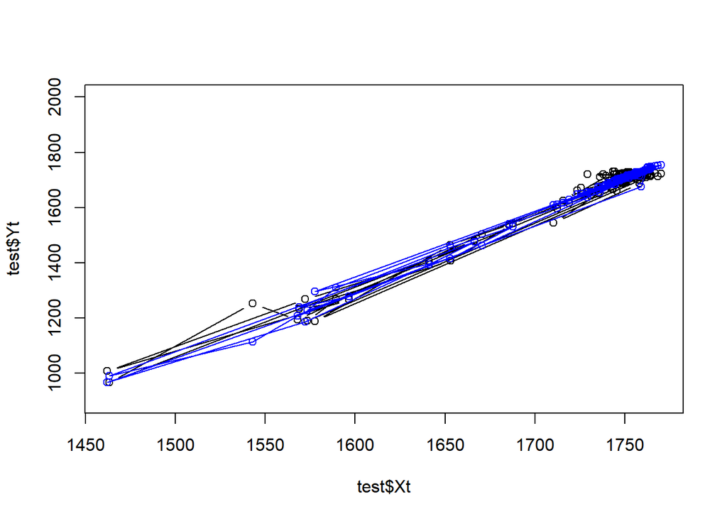

```r
par(mfrow=c(1,1))
plot(test$Xt, test$Yt, type="b", col="black", ylim=c(900,2000))
points(test$Xt, fore.dlm$forecasts,col="blue")
lines(test$Xt, fore.dlm$forecasts,col="blue")
```

####DLM 2

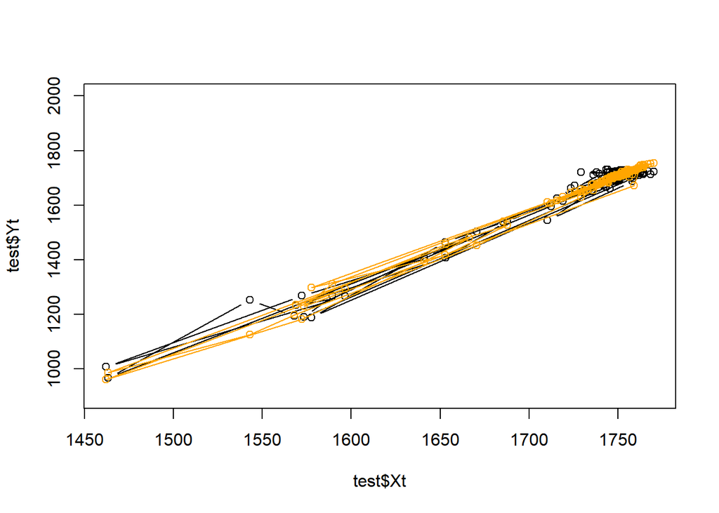

```r
par(mfrow=c(1,1))
plot(test$Xt, test$Yt, type="b", col="black", ylim=c(900,2000))
points(test$Xt, fore.dlm2$forecasts,col="orange")
lines(test$Xt, fore.dlm2$forecasts,col="orange")
```

####ADRL

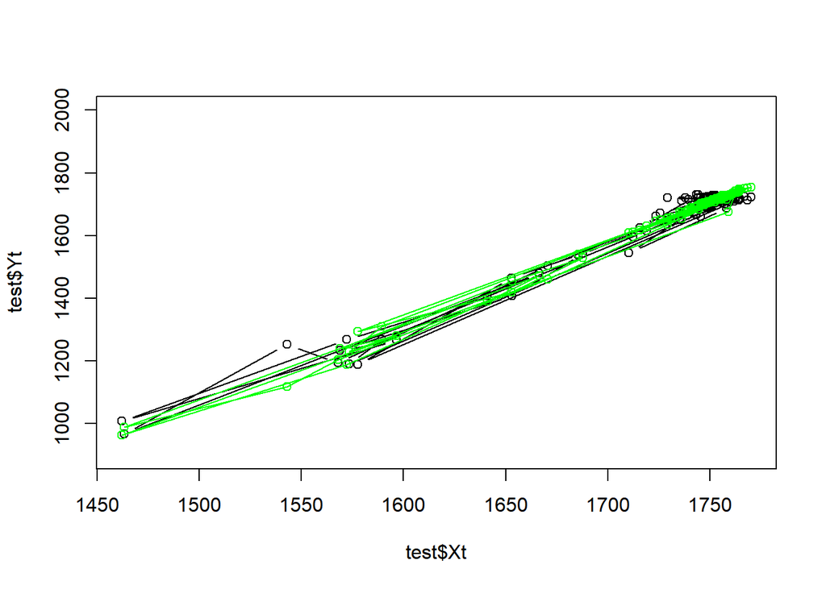

```r
par(mfrow=c(1,1))
plot(test$Xt, test$Yt, type="b", col="black", ylim=c(900,2000))
points(test$Xt, fore.ardl$forecasts,col="green")
lines(test$Xt, fore.ardl$forecasts,col="green")
```

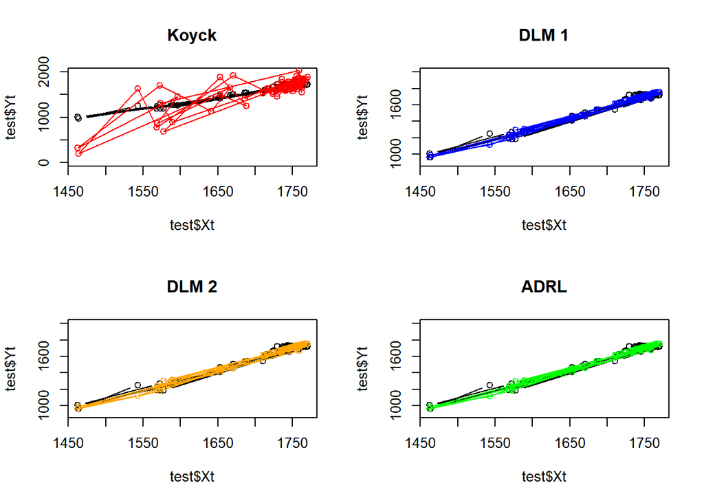

```r
par(mfrow=c(2,2))

# Plot 1
plot(test$Xt, test$Yt, type="b", col="black", ylim=c(0,2000), main = "Koyck")
points(test$Xt, fore.koyck$forecasts,col="red")
lines(test$Xt, fore.koyck$forecasts,col="red")

# Plot 2
plot(test$Xt, test$Yt, type="b", col="black", ylim=c(900,2000), main = "DLM 1")
points(test$Xt, fore.dlm$forecasts,col="blue")
lines(test$Xt, fore.dlm$forecasts,col="blue")

# Plot 3
plot(test$Xt, test$Yt, type="b", col="black", ylim=c(900,2000), main = "DLM 2")
points(test$Xt, fore.dlm2$forecasts,col="orange")
lines(test$Xt, fore.dlm2$forecasts,col="orange")

# Plot 4
plot(test$Xt, test$Yt, type="b", col="black", ylim=c(900,2000), main = "ADRL")
points(test$Xt, fore.ardl$forecasts,col="green")
lines(test$Xt, fore.ardl$forecasts,col="green")
```

Berdasarkan plot tersebut, tidak terlihat perbedaan yang signifikan antara model DLM1, DLM2, dan ADRL karena ketiga metode tersebut memiliki selisih MAPE yang kecil. MAPE terkecil diantara keempat metode tersebut adalah ADRL. Oleh karena itu, model terbaik adalah ADRL.